# IDS investigation worksheet

by Binary_Brigade: Connor Finlay, Ade Obawole, Murray Bone, Alexander Patton & Cameron Smith

2023-12-01

**Note:** You can use this file as you ‘working document’ where you can try out various investigation ideas and keep notes about your findings. How you use and structure this file is up to you. It is recommended that you keep notes about what you are investigating and what you find as this will make the process of creating your presentation and report easier. Please note that you *do not* need to submit this file as part of your group project.

```r
library(tidyverse)
library(cowplot)
library(lubridate)
library(tidymodels)
```

```r
# adding a and e data
aANDe <- read_csv("data/a5f7ca94-c810-41b5-a7c9-25c18d43e5a4.csv")
# adding covid data
covid_nottidy <- read_csv("data/b5e3fa11-8a85-4946-bbb2-2e800d4e3594.csv")
nhs_workforce_nottidy <- read_csv("data/data.csv") # Reads data collected from the NHS Scotland's Turas system about the total amount of vacancies across NHS Scotland's allied health professions. Latest release as of Nov 13 2023 https://turasdata.nes.nhs.scot/data-and-reports/official-workforce-statistics/all-official-statistics-publications/05-september-2023-workforce/dashboards/nhs-scotland-workforce/?pageid=9984
```

```
## ──────────────────────────────────────────────────────── Delimiter: "," chr
## (2): ...3, Vacancy note dbl (1): Value (WTE) dttm (1): Census date
```

sorting Date and Time

```r
unique(aANDe$DepartmentType)
```

```
## [1] "Emergency Department"
```

```r
unique(aANDe$Country)
```

```
## [1] "S92000003"
```

```r
AandE <- aANDe %>%
  mutate(
    weekend_date_correct = ymd(WeekEndingDate),
    quarter = quarter(weekend_date_correct, with_year = TRUE),
    ) %>% # Gets the date information for each observation into the datetime and quarter format
     select(-c(WeekEndingDate, DepartmentType, Country)
         ) # Removes irrelevant (superceded/the same for all observations) from the data set


#renaming columns to be consistent


Covid <- covid_nottidy %>%
   mutate(
     weekend_date_correct = ymd(Date)
   ) %>%
   select(-c(Date))

nhs_workforce <- nhs_workforce_nottidy %>%
  mutate(
    census_date = ymd(`Census date`),
    quarter = quarter(census_date, with_year = TRUE),
    vacancies = `Value (WTE)`
  ) %>%
      select(
        -c(`Census date`,`Value (WTE)`,...3,`Vacancy note`)
      )
```

Summarising wait time over 4 hours based on location of treatment and percentage within 4 hours by year

```r
AandE %>%
  group_by(TreatmentLocation) %>%
  summarise(
    avg_pct_Within4 = mean(PercentageWithin4HoursEpisode),
    avg_pct_Over8 = mean(PercentageOver8HoursEpisode),
    avg_pct_Over12 = mean(PercentageOver12HoursEpisode)
    )
```

```
## # A tibble: 32 × 4
##    TreatmentLocation avg_pct_Within4 avg_pct_Over8 avg_pct_Over12
##    <chr>                       <dbl>         <dbl>          <dbl>
##  1 A111H                        85.8         5.31          2.87
##  2 A210H                        82.9         6.40          3.38
##  3 B120H                        85.1         4.19          2.46
##  4 C121H                        95.9         0.286         0.0608
##  5 C313H                        88.9         1.18          0.217
##  6 C418H                        81.4         4.07          0.844
##  7 F704H                        86.1         2.31          0.503
##  8 G107H                        80.6         2.88          0.498
##  9 G306H                        84.0         2.1           0.446
## 10 G405H                        75.8         4.17          0.971
## # ℹ 22 more rows
```

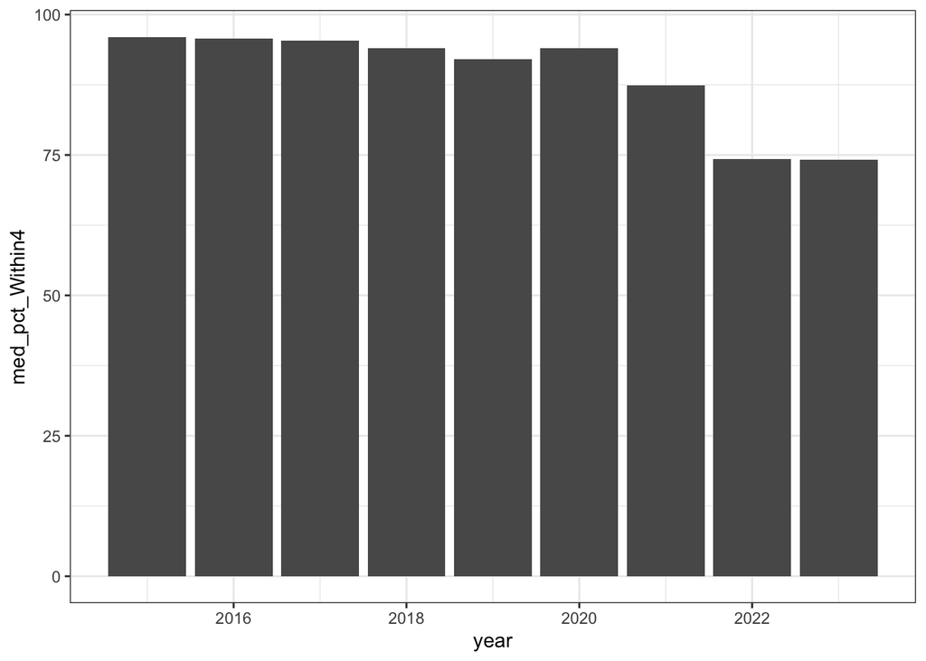

```r
#It is evident that based on the location of the practice, the average amount of people that wait 4/8/12 hours vary drastically. Summarising this allows us to witness what the average amount of wait time is based on individual practice, over all weeks.
AandE %>%
  mutate(year = year(weekend_date_correct)) %>%
  group_by(year) %>%
  summarise(
    med_pct_Within4 = median(PercentageWithin4HoursEpisode) ) %>%
  ggplot( mapping = aes( x = year,
                         y = med_pct_Within4
                         )
          ) +
  geom_bar(stat='identity') +
  theme_bw() # The median percentage seen to within 4 hours seems to decrease over time (especially after 2020) - Why?
```

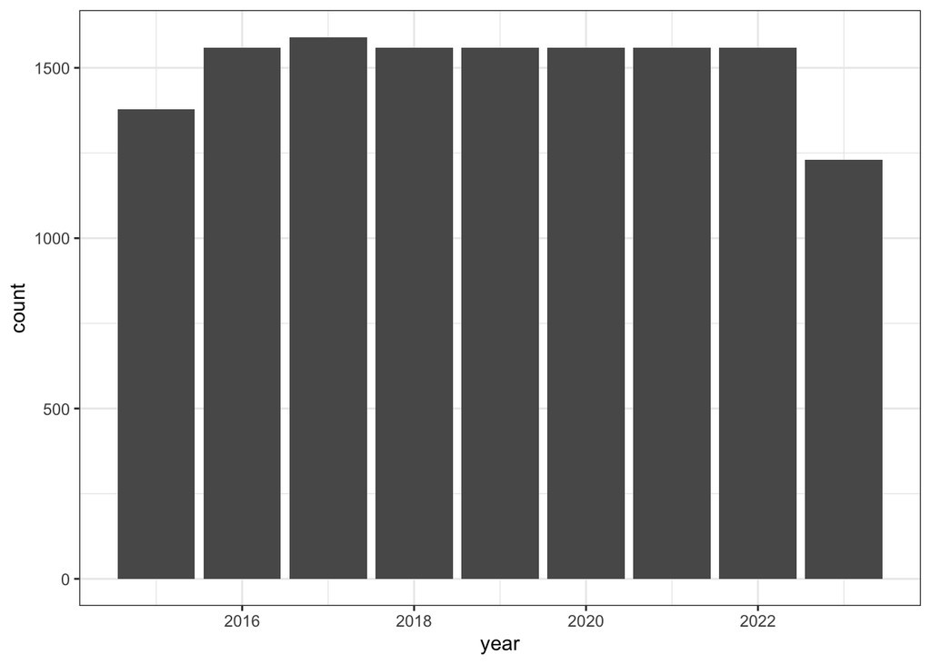

```r
AandE %>%
  mutate(year = year(weekend_date_correct)) %>%
  group_by(year) %>%
  ggplot(
    mapping = aes(
      x = year
    )
    ) +
    geom_bar() +
      theme_bw() # We can see that there is an equivalent amount of observations for each complete year (2016-2022) in this data set; this is because the data was collected into weekly sets for roughly same group of A&Es, meaning that the number of observations was unlikely to change
```

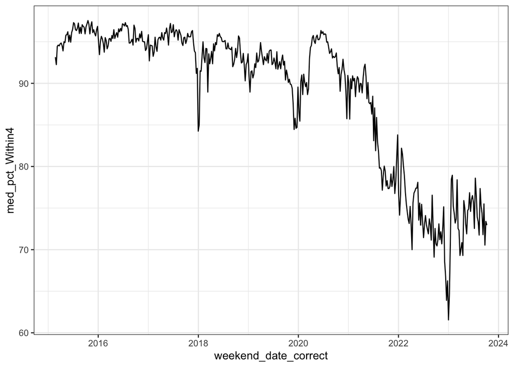

```r
AandE %>%
  group_by(weekend_date_correct) %>%
  summarise(
    med_pct_Within4 = median(PercentageWithin4HoursEpisode)
  ) %>%
  ggplot(
    mapping = aes(
      x = weekend_date_correct,
      y = med_pct_Within4
    )
  ) +
geom_freqpoly(stat="identity") +
  theme_bw() # Gives a more granular view of the trend seen before; the median percentage of attendances seen within 4 hours decreases particularly after 2020. It consistently has much lower values in 2022 and 2023, bottoming out around the beginning of 2023.
```

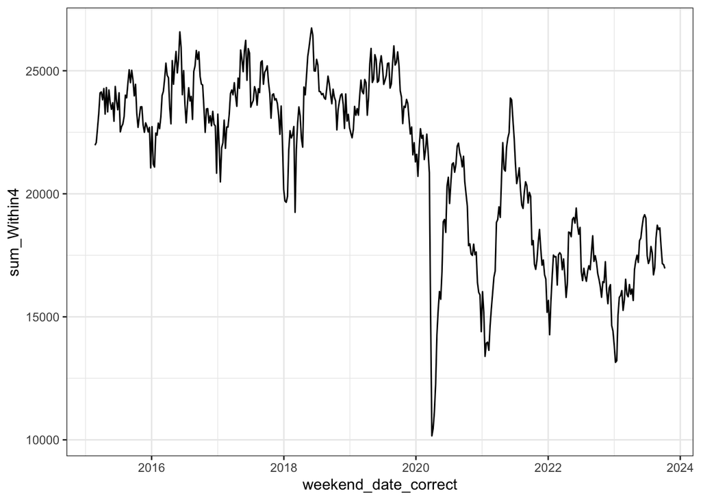

```r
AandE %>%
 group_by(weekend_date_correct) %>%
  summarise(
    sum_Within4 = sum(NumberWithin4HoursEpisode)
  ) %>%
  ggplot(
    mapping = aes(
      x = weekend_date_correct,
      y = sum_Within4
    )
  ) +
geom_freqpoly(stat="identity") +
  theme_bw() # Shows a  more granular tabulation of waits under 4 hours, giving on a weekly basis. This allows us to see that the total number of visits under 4 hours has also decreased since the beginning of the data set, bottoming out in early-to-mid 2020 and staying chaotic but generally low until today.
```

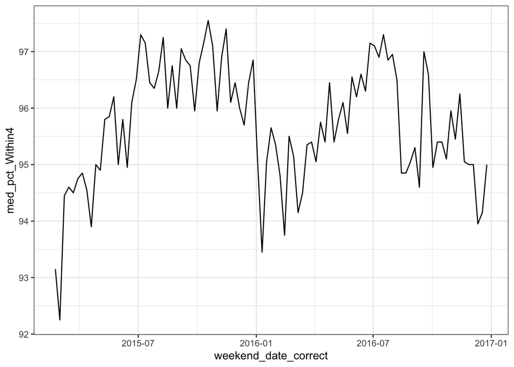

```r
AandE %>%
  group_by(weekend_date_correct) %>%
  filter(year(weekend_date_correct) <= 2016
  ) %>%
  summarise(
    med_pct_Within4 = median(PercentageWithin4HoursEpisode)
  ) %>%
  ggplot(
    mapping = aes(
      x = weekend_date_correct,
      y = med_pct_Within4
    )
  ) +
geom_freqpoly(stat="identity") +
  theme_bw() # Creates a version of the first frequency plot limited to 2015 and 2016 to see if the closure of certain A&Es during 2015 had an effect that would be more noticeable at this scale. Around that time, no significant decrease appears to occur.
```

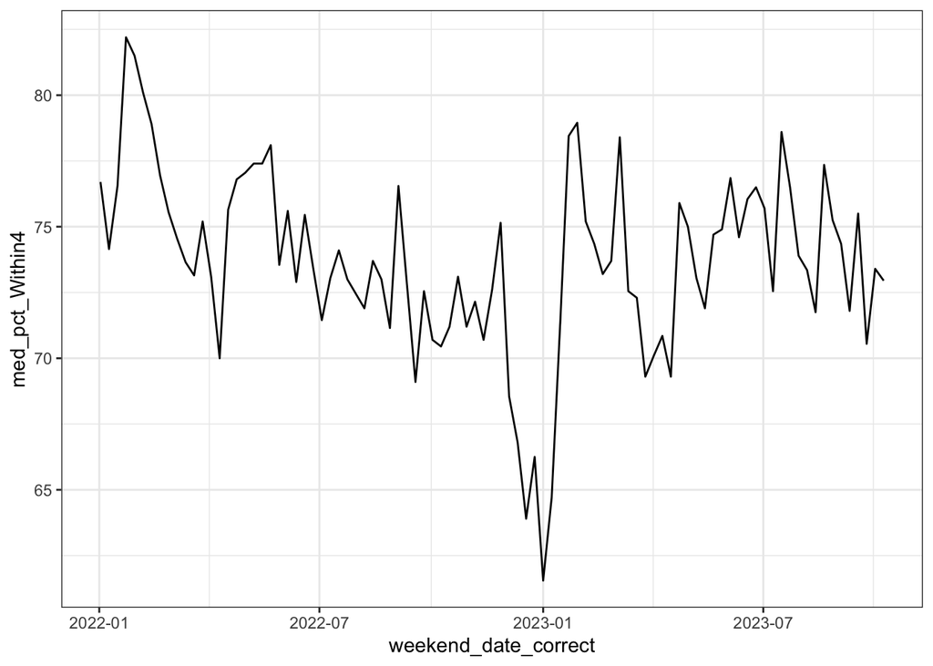

```r
AandE %>%
  group_by(weekend_date_correct) %>%
  filter(year(weekend_date_correct) >= 2022
  ) %>%
  summarise(
    med_pct_Within4 = median(PercentageWithin4HoursEpisode)
  ) %>%
  ggplot(
    mapping = aes(
      x = weekend_date_correct,
      y = med_pct_Within4
    )
  ) +
geom_freqpoly(stat="identity") +
  theme_bw() # Creates a version of the first frequency plot limited to 2022 and 2023 to get a closer look at the minimum at the start of 2023. The surrounding weeks appear to have similarly low values, signifying that this especially low amount of attendances under 4 hours may have been part of some greater trend.
```

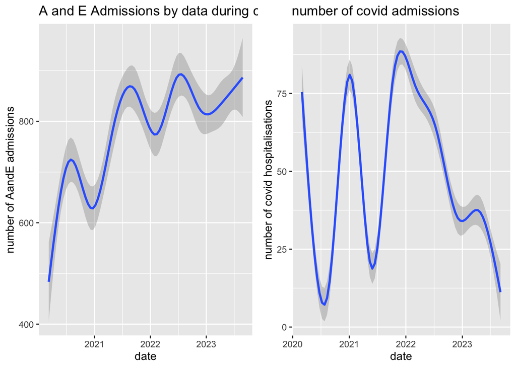

```r
Covidgraph <- AandE %>% filter(weekend_date_correct > ym("2020-03"), weekend_date_correct <= ym("2023-09"))

p1 <- ggplot(Covidgraph, aes(x = weekend_date_correct,
                        y = NumberOfAttendancesEpisode)) +
  geom_smooth() + labs( y = "number of AandE admissions",
                       x = "date",
                        title = "A and E Admissions by data during covid pandemic")

p2 <- ggplot(Covid, aes(x = weekend_date_correct,
                  y = NumberAdmitted)) +
  geom_smooth() + labs(x = "date",
                       y = "number of covid hospitalisations",
                       title = "number of covid admissions")

combined_plot <- plot_grid(p1, p2)
print(combined_plot)
```

```r
#Group AandE admissions by date
Week_data <- AandE %>%
  group_by(weekend_date_correct) %>%
  summarise(total_admitted_AandE = sum(NumberOfAttendancesEpisode))

#change format of COVID data set to a weekly counter
covid_week_data <- Covid %>% group_by(weekend_date_correct =lubridate::floor_date(weekend_date_correct, unit = "week")) %>%
  summarise(total_admitted_COVID = sum(NumberAdmitted))

#Join dataset
AandE_covid <- Week_data %>% full_join(covid_week_data, by = "weekend_date_correct") %>% drop_na()

#Linear reg model
linear_model_covid <- lm(total_admitted_AandE ~ total_admitted_COVID, data = AandE_covid)

summary(linear_model_covid)
```

```
##
## Call:
## lm(formula = total_admitted_AandE ~ total_admitted_COVID, data = AandE_covid)
##
## Residuals:
##    Min     1Q Median     3Q    Max
## -11055  -2082   1167   2363   5519
##
## Coefficients:
##                       Estimate Std. Error t value Pr(>|t|)
## (Intercept)          24415.354    438.286  55.706  < 2e-16 ***
## total_admitted_COVID    -2.800      1.056  -2.651  0.00874 **
## ---
## Signif. codes:  0 '***' 0.001 '**' 0.01 '*' 0.05 '.' 0.1 ' ' 1
##
## Residual standard error: 3482 on 182 degrees of freedom
## Multiple R-squared:  0.03717,    Adjusted R-squared:  0.03188
## F-statistic: 7.025 on 1 and 182 DF,  p-value: 0.008744
```

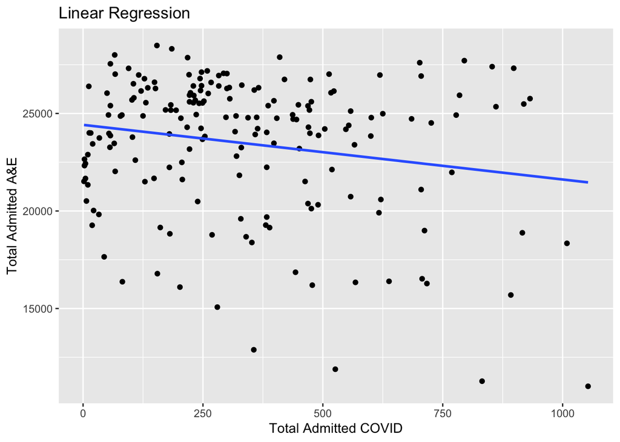

```r
#Plot model
pCOVID <- ggplot(AandE_covid, aes(x = total_admitted_COVID,
                                  y = total_admitted_AandE)) +
  geom_point() +
  geom_smooth(method = "lm", se = FALSE) +
  labs(title = "Linear Regression",
       x = "Total Admitted COVID",
       y = "Total Admitted A&E")

print(pCOVID)
```

```r
AandE$Z_Score_Within4Hours <- scale(AandE$PercentageWithin4HoursEpisode)
outlier_threshold <- 3
outliers_within4hours <- AandE[abs(AandE$Z_Score_Within4Hours) > outlier_threshold, ]
print(outliers_within4hours)
```

```
## # A tibble: 299 × 14
##    `_id` HBT     TreatmentLocation NumberOfAttendancesE…¹ NumberWithin4HoursEp…²
##    <dbl> <chr>   <chr>                              <dbl>                  <dbl>
##  1 10302 S08000… G405H                               1674                    750
##  2 10386 S08000… V217H                               1180                    575
##  3 10416 S08000… V217H                               1161                    475
##  4 10446 S08000… V217H                               1164                    548
##  5 10482 S08000… G405H                               1695                    803
##  6 10626 S08000… V217H                               1079                    478
##  7 10656 S08000… V217H                               1119                    539
##  8 10657 S08000… N101H                                967                    466
##  9 10686 S08000… V217H                               1103                    551
## 10 10703 S08000… S314H                               2247                   1138
## # ℹ 289 more rows
## # ℹ abbreviated names: ¹NumberOfAttendancesEpisode, ²NumberWithin4HoursEpisode
## # ℹ 9 more variables: NumberOver4HoursEpisode <dbl>,
## #   PercentageWithin4HoursEpisode <dbl>, NumberOver8HoursEpisode <dbl>,
## #   PercentageOver8HoursEpisode <dbl>, NumberOver12HoursEpisode <dbl>,
## #   PercentageOver12HoursEpisode <dbl>, weekend_date_correct <date>,
## #   quarter <dbl>, Z_Score_Within4Hours <dbl[,1]>
```

This analysis calculates Z-scores for ‘PercentageWithin4HoursEpisode,’ helping us spot outliers which are data points that are significantly different from the average waiting time. I’ve set a threshold at 3 standard deviations meaning that if a week’s Z-score exceeds 3 or falls below -3, it’s flagged as an outlier in the ‘outliers_within4hours’ data frame. This helps us focus on weeks with unusual waiting time patterns.

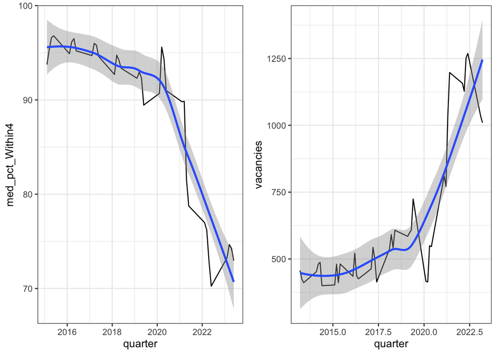

```r
p3 <- AandE %>%
  mutate(year = year(weekend_date_correct)) %>%
  group_by(quarter) %>%
  summarise(
    med_pct_Within4 = median(PercentageWithin4HoursEpisode) ) %>%
  ggplot( mapping = aes(
    x = quarter,
    y = med_pct_Within4
                         )
          ) +
  geom_freqpoly(stat='identity') +
  geom_smooth() +
  theme_bw() # Creates a plot of median percentage of waiting times for quarter of data collection to compare against a similar plot of vacancies

p4 <- nhs_workforce %>%
  ggplot(
    mapping = aes(
      x = quarter,
      y = vacancies
    )
  ) +
  geom_freqpoly(stat="identity") +
  geom_smooth() +
  theme_bw() # Creates a plot of median percentage of vacancies among allied health NHS Scotland workers for every quarter of data collection to compare against the above plot

  plot_grid(p3, p4) # Creates a plot grid of the last two plots to more easily compare their shapes and trends
```

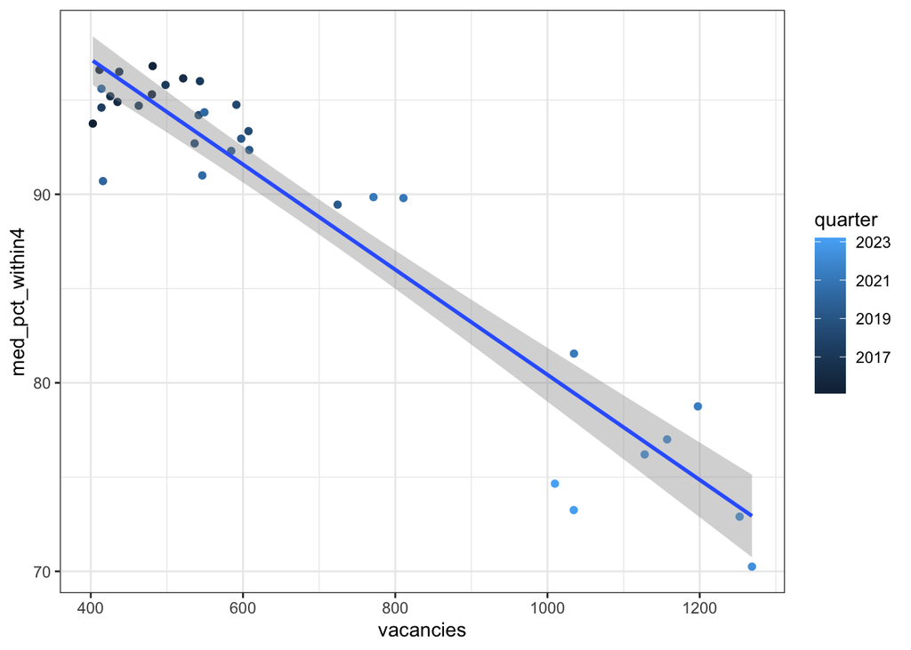

```r
  AandE_work <- AandE %>%
    inner_join(
      by = "quarter",
      nhs_workforce
    ) %>%
    group_by(quarter) %>%
      summarise(
        med_pct_within4 = median(PercentageWithin4HoursEpisode),
        vacancies = median(vacancies)
      )
 p5 <- AandE_work %>%
    ggplot(
      mapping = aes(
        x = vacancies,
        y = med_pct_within4,
        colour = quarter
      )
    ) +
    geom_point() +
    geom_smooth(method='lm') +
    theme_bw()

  p5 # Plots the median percentage of visits within 4 hours for a certain quarter against the vacancies recorded for that quarter and fits a preliminary linear model to it. DO A PROPER LINEA$R REGRESSION
```

From the above preliminary data visualisations, it seems that the portion of A&E visits seen to in 4 hours, in Scotland for a given quarter, can be inversely related to the amount of vacancies (Whole Time Equivalent) wihtin NHS Scotland.

```r
AEW_fit <- linear_reg() %>% # Initiates a linear regression
  set_engine("lm") %>% # Gives this linear regression a linear model engine
    fit(med_pct_within4 ~ vacancies,
        data = AandE_work,
        family = "binomial"
    )
tidy(AEW_fit)
```

```
## # A tibble: 2 × 5
##   term        estimate std.error statistic  p.value
##   <chr>          <dbl>     <dbl>     <dbl>    <dbl>
## 1 (Intercept) 108.       1.19         90.9 3.43e-40
## 2 vacancies    -0.0279   0.00164     -17.0 1.32e-17
```